# Business Understanding

### Overview:

> Due to intense competition in the telecommunications sector, predicting customer churn has become a critical concern for SyriaTel. Retaining customers is vital for maintaining competitiveness, as it is more cost-effective than acquiring new ones. Therefore, it is crucial to develop strategies to prevent customer loss. By analyzing various data points and employing predictive analytics, SyriaTel can identify patterns and indicators to anticipate customer behavior and implement proactive measures to reduce churn rates. SyriaTel seeks to use predictive machine learning models, incorporating demographics such as location and usage patterns like calls and charges, to predict the likelihood of customer churn. It is essential for the company to continuously update these models to reflect evolving customer behavior and market dynamics to ensure the effectiveness of its retention strategies.

### Problem Statement:

> SyriaTel faces heightened competition in the telecommunications industry, making customer retention a critical concern. Predicting customer churn accurately is essential to retain customers and stay competitive. The company needs effective strategies to prevent customer loss and reduce churn rates.

### Proposed Solution:

> To address the challenge of predicting customer churn, SyriaTel plans to utilize predictive machine learning models. These models will analyze various data points, including demographics (such as location) and usage patterns (such as calls and charges), to identify patterns and indicators of potential churn. By employing predictive analytics, SyriaTel aims to anticipate customer behavior and implement proactive measures to retain customers. It is crucial to continuously update these models to adapt to evolving customer behavior and market dynamics.

### Metrics:

> The effectiveness of SyriaTel's predictive models will be evaluated based on the accuracy score. This metric measures the proportion of correctly predicted instances among all instances, providing insight into how well the models can predict customer churn. A higher accuracy score indicates that the models are more reliable in identifying customers likely to churn, enabling SyriaTel to take preemptive actions to retain them.

# Objectives

- Develop machine learning models to predict customer churn by analyzing customer feature data.
- Compare these models to determine which one offers the highest prediction accuracy.
- The goal of the analysis is to pinpoint specific features that significantly influence the customer churn rate at SyriaTel, and provide valuable recommendations based on these insights to help reduce churn rates and enhance customer retention.

## Summary of Features in the Dataset

- state: state residency of the customer
- account length: the number of days the customer has owned the account
- area code: area code of the customer
- phone number: phone number of the customer
- international plan: true if the customer has the international plan, otherwise false
- voice mail plan: true if the customer has the voice mail plan, otherwise false
- number vmail messages: number of voicemails the customer has sent
- total day minutes: total number of minutes the customer has been in calls during the day
- total day calls: total number of calls the user has done during the day
- total day charge: total amount of money the customer was charged by the Telecom company for calls during the day
- total eve minutes: total number of minutes the customer has been in calls during the evening
- total eve calls: total number of calls the customer has done during the evening
- total eve charge: total amount of money the customer was charged by the Telecom company for calls during the evening
- total night minutes: total number of minutes the customer has been in calls during the night
- total night calls: total number of calls the customer has done during the night
- total night charge: total amount of money the customer was charged by the Telecom company for calls during the night
- total intl minutes: total number of minutes the user has been in international calls
- total intl calls: total number of international calls the customer has done
- total intl charge: total amount of money the customer was charged by the Telecom company for international calls
- customer service calls: number of calls the customer made to customer service
- churn: true if the customer terminated their contract, otherwise false

### Data Understanding

> This helps to us to acquire knowledge and comprehension about this dataset before further analysis and modeling.

```python
#importing relevant libraries
import pandas as pd
import numpy as np
import matplotlib.pyplot as plt
%matplotlib inline
import seaborn as sns
from sklearn.preprocessing import LabelEncoder
from sklearn.model_selection import train_test_split, cross_val_score
from sklearn.preprocessing import OneHotEncoder
from sklearn.metrics import roc_auc_score, ConfusionMatrixDisplay, classification_report, accuracy_score, confusion_matrix, roc_curve
from sklearn.preprocessing import StandardScaler
import warnings
from imblearn.over_sampling import SMOTE
from sklearn.linear_model import LogisticRegression
from sklearn.tree import DecisionTreeClassifier
from sklearn.ensemble import RandomForestClassifier
from sklearn.model_selection import GridSearchCV
from sklearn.model_selection import cross_val_score
import multiprocessing # for reducing the runtime of gridsearch
from sklearn.feature_selection import SelectFromModel
from sklearn.linear_model import LogisticRegressionCV

# Ignore warnings
warnings.filterwarnings("ignore")
```

```python
 #read csv file and check the data
syriatel = pd.read_csv('bigml.csv')
syriatel.head()
```

|  | state | account length | area code | phone number | international plan | voice mail plan | number vmail messages | total day minutes | total day calls | total day charge | ... | total eve calls | total eve charge | total night minutes | total night calls | total night charge | total intl minutes | total intl calls | total intl charge | customer service calls | churn |
| --- | --- | --- | --- | --- | --- | --- | --- | --- | --- | --- | --- | --- | --- | --- | --- | --- | --- | --- | --- | --- | --- |
| 0 | KS | 128 | 415 | 382-4657 | no | yes | 25 | 265.1 | 110 | 45.07 | ... | 99 | 16.78 | 244.7 | 91 | 11.01 | 10.0 | 3 | 2.70 | 1 | False |
| 1 | OH | 107 | 415 | 371-7191 | no | yes | 26 | 161.6 | 123 | 27.47 | ... | 103 | 16.62 | 254.4 | 103 | 11.45 | 13.7 | 3 | 3.70 | 1 | False |
| 2 | NJ | 137 | 415 | 358-1921 | no | no | 0 | 243.4 | 114 | 41.38 | ... | 110 | 10.30 | 162.6 | 104 | 7.32 | 12.2 | 5 | 3.29 | 0 | False |
| 3 | OH | 84 | 408 | 375-9999 | yes | no | 0 | 299.4 | 71 | 50.90 | ... | 88 | 5.26 | 196.9 | 89 | 8.86 | 6.6 | 7 | 1.78 | 2 | False |
| 4 | OK | 75 | 415 | 330-6626 | yes | no | 0 | 166.7 | 113 | 28.34 | ... | 122 | 12.61 | 186.9 | 121 | 8.41 | 10.1 | 3 | 2.73 | 3 | False |

5 rows × 21 columns

```python
#check the shape of the data
syriatel.shape
```

```
(3333, 21)
```

```python
# check for data information
syriatel.info()
```

```
<class 'pandas.core.frame.DataFrame'>
RangeIndex: 3333 entries, 0 to 3332
Data columns (total 21 columns):
 #   Column                  Non-Null Count  Dtype
---  ------                  --------------  -----
 0   state                   3333 non-null   object
 1   account length          3333 non-null   int64
 2   area code               3333 non-null   int64
 3   phone number            3333 non-null   object
 4   international plan      3333 non-null   object
 5   voice mail plan         3333 non-null   object
 6   number vmail messages   3333 non-null   int64
 7   total day minutes       3333 non-null   float64
 8   total day calls         3333 non-null   int64
 9   total day charge        3333 non-null   float64
 10  total eve minutes       3333 non-null   float64
 11  total eve calls         3333 non-null   int64
 12  total eve charge        3333 non-null   float64
 13  total night minutes     3333 non-null   float64
 14  total night calls       3333 non-null   int64
 15  total night charge      3333 non-null   float64
 16  total intl minutes      3333 non-null   float64
 17  total intl calls        3333 non-null   int64
 18  total intl charge       3333 non-null   float64
 19  customer service calls  3333 non-null   int64
 20  churn                   3333 non-null   bool
dtypes: bool(1), float64(8), int64(8), object(4)
memory usage: 524.2+ KB
```

- The columns of phone number and account length are not important for this analysis hence we drop them.
- The dataset contains categorical and numerical columns.

## Summary of Features in the Dataset

- state: the state the customer lives in
- account length: the number of days the customer has had an account
- area code: the area code of the customer
- phone number: the phone number of the customer
- international plan: true if the customer has the international plan, otherwise false
- voice mail plan: true if the customer has the voice mail plan, otherwise false
- number vmail messages: the number of voicemails the customer has sent
- total day minutes: total number of minutes the customer has been in calls during the day
- total day calls: total number of calls the user has done during the day
- total day charge: total amount of money the customer was charged by the Telecom company for calls during the day
- total eve minutes: total number of minutes the customer has been in calls during the evening
- total eve calls: total number of calls the customer has done during the evening
- total eve charge: total amount of money the customer was charged by the Telecom company for calls during the evening
- total night minutes: total number of minutes the customer has been in calls during the night
- total night calls: total number of calls the customer has done during the night
- total night charge: total amount of money the customer was charged by the Telecom company for calls during the night
- total intl minutes: total number of minutes the user has been in international calls
- total intl calls: total number of international calls the customer has done
- total intl charge: total amount of money the customer was charged by the Telecom company for international calls
- customer service calls: number of calls the customer has made to customer service
- churn: true if the customer terminated their contract, otherwise false

## Data Cleaning and Preparation

> This section prepares the data for EDA and modeling. The dataset will be checked for:
- duplicated rows
- missing values

```python
# missing values
syriatel.isnull().sum()
```

```
state                     0
account length            0
area code                 0
phone number              0
international plan        0
voice mail plan           0
number vmail messages     0
total day minutes         0
total day calls           0
total day charge          0
total eve minutes         0
total eve calls           0
total eve charge          0
total night minutes       0
total night calls         0
total night charge        0
total intl minutes        0
total intl calls          0
total intl charge         0
customer service calls    0
churn                     0
dtype: int64
```

```python
# check for duplicates
syriatel.duplicated().sum()
```

```
0
```

## Exploratory Data Analysis

```python
# the number of unique values for each column in the dataset
syriatel.nunique()
```

```
state                       51
account length             212
area code                    3
phone number              3333
international plan           2
voice mail plan              2
number vmail messages       46
total day minutes         1667
total day calls            119
total day charge          1667
total eve minutes         1611
total eve calls            123
total eve charge          1440
total night minutes       1591
total night calls          120
total night charge         933
total intl minutes         162
total intl calls            21
total intl charge          162
customer service calls      10
churn                        2
dtype: int64
```

### Dropping Some Columns From The Dataset.

> Dropped the account length, phone number, state, and area code columns due to the following reasons:
- The phone number lacks information about customer behavior.
- The account length is not a reliable measure of the client's tenure as a customer in this context. Assuming the account length accurately represents customer loyalty would be invalid without additional information.
- Including the area code and state in the dataset restricts predictions to specific areas, making predictions beyond the defined locations unfeasible.

```python
# List of columns to drop
col_drop = ['account length', 'phone number', 'area code', 'state']

# Check which columns exist in the DataFrame
existing_cols = [col for col in col_drop if col in syriatel.columns]

# Drop the existing columns
syriatel.drop(columns=existing_cols, inplace=True)

syriatel.head()
```

|  | international plan | voice mail plan | number vmail messages | total day minutes | total day calls | total day charge | total eve minutes | total eve calls | total eve charge | total night minutes | total night calls | total night charge | total intl minutes | total intl calls | total intl charge | customer service calls | churn |
| --- | --- | --- | --- | --- | --- | --- | --- | --- | --- | --- | --- | --- | --- | --- | --- | --- | --- |
| 0 | no | yes | 25 | 265.1 | 110 | 45.07 | 197.4 | 99 | 16.78 | 244.7 | 91 | 11.01 | 10.0 | 3 | 2.70 | 1 | False |
| 1 | no | yes | 26 | 161.6 | 123 | 27.47 | 195.5 | 103 | 16.62 | 254.4 | 103 | 11.45 | 13.7 | 3 | 3.70 | 1 | False |
| 2 | no | no | 0 | 243.4 | 114 | 41.38 | 121.2 | 110 | 10.30 | 162.6 | 104 | 7.32 | 12.2 | 5 | 3.29 | 0 | False |
| 3 | yes | no | 0 | 299.4 | 71 | 50.90 | 61.9 | 88 | 5.26 | 196.9 | 89 | 8.86 | 6.6 | 7 | 1.78 | 2 | False |
| 4 | yes | no | 0 | 166.7 | 113 | 28.34 | 148.3 | 122 | 12.61 | 186.9 | 121 | 8.41 | 10.1 | 3 | 2.73 | 3 | False |

```python
#separating categorical and numerical colums for easier analysis
numerical_df = syriatel[['number vmail messages',
       'total day minutes', 'total day calls', 'total day charge',
       'total eve minutes', 'total eve calls', 'total eve charge',
       'total night minutes', 'total night calls', 'total night charge',
       'total intl minutes', 'total intl calls', 'total intl charge',
       'customer service calls']]
categorical_df = syriatel[['churn', 'international plan', 'voice mail plan']]
```

### Data exploration

```python
# Categorical columns
cat_columns = ['international plan', 'voice mail plan', 'churn']

# Continuous columns
cont_columns = ['number vmail messages', 'total day minutes', 'total day calls',
                'total day charge', 'total eve minutes', 'total eve calls',
                'total eve charge', 'total night minutes', 'total night calls',
                'total night charge', 'total intl minutes', 'total intl calls',
                'total intl charge', 'customer service calls']
```

### Checking for NaN values

```python
#checking for missing values
syriatel.isna().sum()
```

```
international plan        0
voice mail plan           0
number vmail messages     0
total day minutes         0
total day calls           0
total day charge          0
total eve minutes         0
total eve calls           0
total eve charge          0
total night minutes       0
total night calls         0
total night charge        0
total intl minutes        0
total intl calls          0
total intl charge         0
customer service calls    0
churn                     0
dtype: int64
```

```python
#checking for duplicates
syriatel.duplicated().value_counts()
```

```
False    3333
dtype: int64
```

> From the above data checking we have got no missing values and no duplicates value. Our data is ready for further analysis.

## Explanatory Data Analysis

```python
syriatel.describe()
```

|  | number vmail messages | total day minutes | total day calls | total day charge | total eve minutes | total eve calls | total eve charge | total night minutes | total night calls | total night charge | total intl minutes | total intl calls | total intl charge | customer service calls |
| --- | --- | --- | --- | --- | --- | --- | --- | --- | --- | --- | --- | --- | --- | --- |
| count | 3333.000000 | 3333.000000 | 3333.000000 | 3333.000000 | 3333.000000 | 3333.000000 | 3333.000000 | 3333.000000 | 3333.000000 | 3333.000000 | 3333.000000 | 3333.000000 | 3333.000000 | 3333.000000 |
| mean | 8.099010 | 179.775098 | 100.435644 | 30.562307 | 200.980348 | 100.114311 | 17.083540 | 200.872037 | 100.107711 | 9.039325 | 10.237294 | 4.479448 | 2.764581 | 1.562856 |
| std | 13.688365 | 54.467389 | 20.069084 | 9.259435 | 50.713844 | 19.922625 | 4.310668 | 50.573847 | 19.568609 | 2.275873 | 2.791840 | 2.461214 | 0.753773 | 1.315491 |
| min | 0.000000 | 0.000000 | 0.000000 | 0.000000 | 0.000000 | 0.000000 | 0.000000 | 23.200000 | 33.000000 | 1.040000 | 0.000000 | 0.000000 | 0.000000 | 0.000000 |
| 25% | 0.000000 | 143.700000 | 87.000000 | 24.430000 | 166.600000 | 87.000000 | 14.160000 | 167.000000 | 87.000000 | 7.520000 | 8.500000 | 3.000000 | 2.300000 | 1.000000 |
| 50% | 0.000000 | 179.400000 | 101.000000 | 30.500000 | 201.400000 | 100.000000 | 17.120000 | 201.200000 | 100.000000 | 9.050000 | 10.300000 | 4.000000 | 2.780000 | 1.000000 |
| 75% | 20.000000 | 216.400000 | 114.000000 | 36.790000 | 235.300000 | 114.000000 | 20.000000 | 235.300000 | 113.000000 | 10.590000 | 12.100000 | 6.000000 | 3.270000 | 2.000000 |
| max | 51.000000 | 350.800000 | 165.000000 | 59.640000 | 363.700000 | 170.000000 | 30.910000 | 395.000000 | 175.000000 | 17.770000 | 20.000000 | 20.000000 | 5.400000 | 9.000000 |

> This method offers a rapid summary of a dataset's central tendency, dispersion, and distribution shape, making it especially useful for obtaining an overview of the data.

## Relationship Visualization

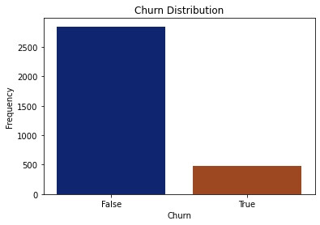

```
False    2850
True      483
Name: churn, dtype: int64
```

```python
# Distribution of Churn
sns.countplot(x='churn', data=syriatel, palette='dark')
plt.title('Churn Distribution')
plt.xlabel('Churn')
plt.ylabel('Frequency')
plt.show()

print(syriatel['churn'].value_counts())
```

> From the above visulization it clearly shows that most of the customers are more loyal to SyriaTel.

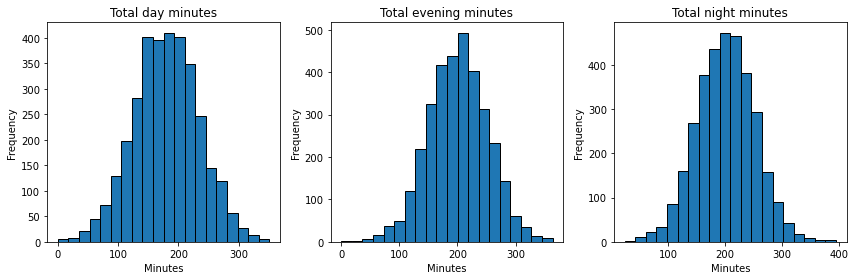

```python
#total charge of calls per area code

# Create subplots for each variable
fig, axs = plt.subplots(1, 3, figsize=(12, 4))

# Plot histograms for each variable
axs[0].hist(syriatel['total day minutes'], bins=20, edgecolor='k')
axs[0].set_title('Total day minutes')
axs[0].set_xlabel('Minutes')
axs[0].set_ylabel('Frequency')

axs[1].hist(syriatel['total eve minutes'], bins=20, edgecolor='k')
axs[1].set_title('Total evening minutes')
axs[1].set_xlabel('Minutes')
axs[1].set_ylabel('Frequency')

axs[2].hist(syriatel['total night minutes'], bins=20, edgecolor='k')
axs[2].set_title('Total night minutes')
axs[2].set_xlabel('Minutes')
axs[2].set_ylabel('Frequency')

# Adjust spacing between subplots
plt.tight_layout()

# Display the plots
plt.show()
```

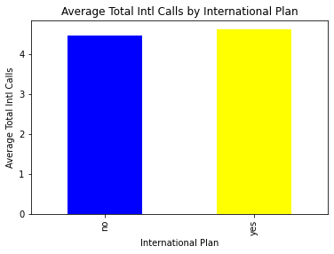

```python
#the international calls made by people
# Group by 'international plan' and calculate the mean of 'total intl calls'
grouped_data = syriatel.groupby('international plan')['total intl calls'].mean()

# Plot the bar plot
fig, ax = plt.subplots()
grouped_data.plot(kind='bar', color=['blue', 'yellow'], ax=ax)

# Add labels and title to the plot
ax.set_xlabel('International Plan')
ax.set_ylabel('Average Total Intl Calls')
ax.set_title('Average Total Intl Calls by International Plan')

# Display the plot
plt.show()
```

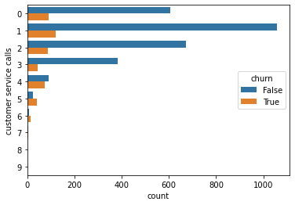

```python
#Relationship between the number of calls to the call center and loyalty

sns.countplot(y='customer service calls', hue='churn', data=syriatel)
```

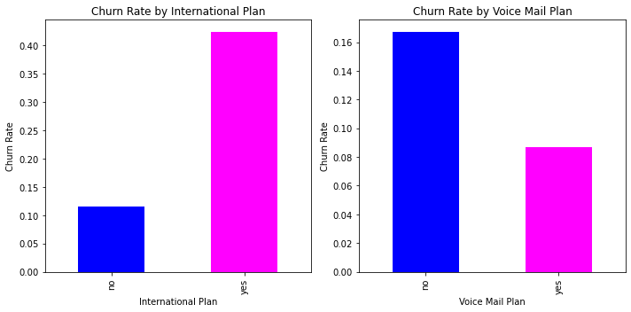

```python
#visualizing for the international calls made by people
# Map the values in 'voice mail plan' column to labels

# Create a figure with one row and two columns
fig, axes = plt.subplots(1, 2, figsize=(10, 5))

# Plot the first subplot: International Plan
syriatel.groupby('international plan')['churn'].mean().plot(kind='bar', ax=axes[0], color=['blue', 'magenta'])
axes[0].set_xlabel('International Plan')
axes[0].set_ylabel('Churn Rate')
axes[0].set_title('Churn Rate by International Plan')

# Plot the second subplot: Voice Mail Plan
syriatel.groupby('voice mail plan')['churn'].mean().plot(kind='bar', ax=axes[1], color=['blue', 'magenta'])
axes[1].set_xlabel('Voice Mail Plan')
axes[1].set_ylabel('Churn Rate')
axes[1].set_title('Churn Rate by Voice Mail Plan')

# Adjust the spacing between subplots
plt.tight_layout()

# Display the plot
plt.show()
```

- Looking at the graph above it shows that more customers loyalty is beacause of Voice mail plan subscribers due to lower churn rate
- Customers have higher rate of churn from Syriatel in terms of international plan.
- This shows that customers are more happy with voice mail than international plan.

### Outliers

```python
def find_outliers(df):
    outliers = {}
    for column in df.columns:
        data = df[column].dropna()  # Drop NaN values
        q1 = np.percentile(data, 25)
        q3 = np.percentile(data, 75)
        iqr = q3 - q1
        lower_bound = q1 - 1.5 * iqr
        upper_bound = q3 + 1.5 * iqr

        outliers[column] = data[(data < lower_bound) | (data > upper_bound)].sum()
    return outliers

# Example usage with numerical_df
outliers_sum = find_outliers(numerical_df)
print(outliers_sum)
```

[output not shown]

```python
import numpy as np

def find_outliers(data):
    """
    Finds outliers in a dataset using the interquartile range (IQR) method.

    Parameters:
    - data: A list or numpy array of numerical values.

    Returns:
    - outliers: A list of the outlier values.
    """
    q1, q3 = np.percentile(data, [25, 75])
    iqr = q3 - q1
    lower_bound = q1 - 1.5 * iqr
    upper_bound = q3 + 1.5 * iqr

    outliers = [x for x in data if x < lower_bound or x > upper_bound]
    return outliers
```

```python
def find_outliers(df):
    outliers = {}
    for column in df.columns:
        # Ensure the column is numeric
        if pd.api.types.is_numeric_dtype(df[column]):
            data = df[column].dropna()  # Drop NaN values
            q1 = np.percentile(data, 25)
            q3 = np.percentile(data, 75)
            iqr = q3 - q1
            lower_bound = q1 - 1.5 * iqr
            upper_bound = q3 + 1.5 * iqr

            outliers[column] = data[(data < lower_bound) | (data > upper_bound)].sum()
        else:
            outliers[column] = 0  # If the column is not numeric, set outliers sum to 0
    return outliers

# Example usage with numerical_df
outliers_sum_dict = find_outliers(numerical_df)
outliers_sum_total = sum(outliers_sum_dict.values())
print(outliers_sum_total)
```

```
24528.96
```

```python
def remove_outliers(data):
    # Calculating the quartiles and IQR
    Q1 = data.quantile(0.25)
    Q3 = data.quantile(0.75)
    IQR = Q3 - Q1

    # Determining the lower and upper bounds
    lower_bound = Q1 - 1.5 * IQR
    upper_bound = Q3 + 1.5 * IQR

    # Removing outliers
    filtered_data = data[(data >= lower_bound) & (data <= upper_bound)]

    return filtered_data
```

```python
#using the function above to remove outliers
filtered_data = remove_outliers(numerical_df)
```

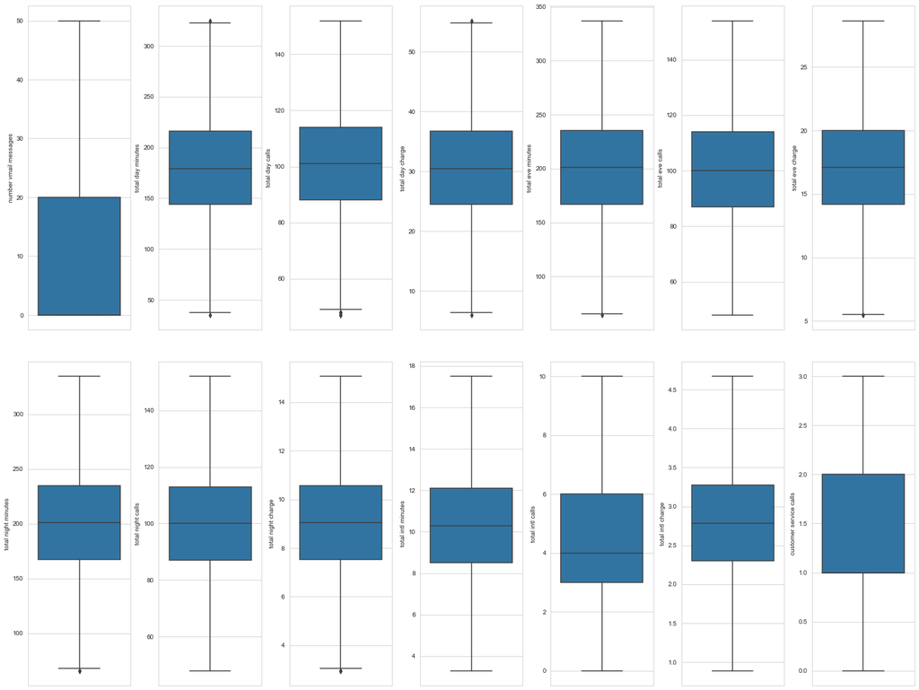

```python
#checking for any outliers in the dataset using box plot
# visualizing with matplotlib and seaborn
sns.set_style('whitegrid')
fig,ax = plt.subplots(ncols=7,nrows =2,figsize = (20,15))
index = 0
ax = ax.flatten()
for col,value in filtered_data.items():
    sns.boxplot(y = col,data = filtered_data,ax = ax[index])
    index += 1
plt.tight_layout(pad= 0.5,w_pad= 0.7,h_pad=5.0)

plt.savefig("Images/outliers.png")
```

## Data Preparation

### Important features

> We will use heatmap to determine correlation which help in identfying the important features

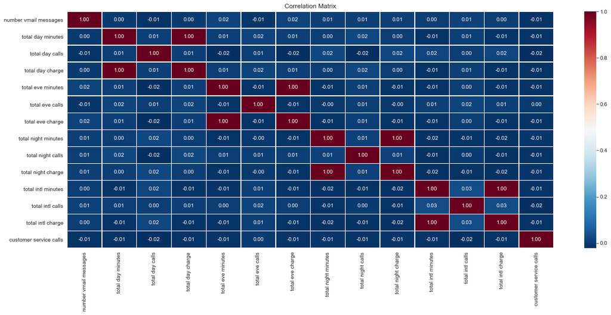

```python
#using heatmap to check for correlation
correlation_matrix = numerical_df.corr()
plt.figure(figsize=(20, 8))
sns.heatmap(correlation_matrix, annot=True, cmap='RdBu_r', fmt=".2f", linewidths=0.5)
plt.title('Correlation Matrix')
plt.show()
```

- As seen from the heatmap there are some variables that have 1 that is perfect correlation with other variables.
- Multicollinearity will occur if this predictor variables are highly correlated, which can lead to instability and unreliable estimates of the model parameters.
- Hence we will remove one of the correlacetd factors which is total day minutes, total eve minutes, /total night minutes and total intl minutes

```python
#droping features with perfect correlation using our previous seriatel_df
syriatel_1 = syriatel.drop(columns=['total day minutes', 'total eve minutes', 'total night minutes', 'total intl minutes'], axis=1)
```

```python
#checking for the shape of the data
syriatel_1.shape
```

[output not shown]

### Transforming categorical variables using OHE

```python
#transformimg categorical data using OHE

# Select the categorical columns to be one-hot encoded
categorical_df = ['international plan', 'voice mail plan']

# Create an instance of the OneHotEncoder
encoder = OneHotEncoder()

# Fit and transform the categorical columns
encoded_data = encoder.fit_transform(syriatel_1[categorical_df])

# Convert the encoded data to a DataFrame
encoded_df = pd.DataFrame(encoded_data.toarray(), columns=encoder.get_feature_names(categorical_df))

# Concatenate the encoded DataFrame with the remaining columns from the original DataFrame
syriatel_data = pd.concat([syriatel_1.drop(categorical_df, axis=1), encoded_df], axis=1)

syriatel_data
```

[output not shown]

3333 rows × 16 columns

```python
#convert churn using label ecoder using a function
def encode(column):
    le = LabelEncoder()
    syriatel_data[column] = le.fit_transform(syriatel_data[column])
#encoding the column
encode('churn')
#checking for encorded churn column
syriatel_data.churn.value_counts()
```

```
0    2850
1     483
Name: churn, dtype: int64
```

## Train-Test Splitting

> This will be used to test the data and used to evaluate the performance of the trained model on unseen data. By evaluating the model on the test set, we can get an estimate of how well the model generalizes to new, unseen data.

```python
# Split the data into features (X) and target variable (y)
X = syriatel_data.drop(columns='churn', axis=1)
y = syriatel_data['churn']

# Perform train-test split
X_train, X_test, y_train, y_test = train_test_split(X, y, test_size=0.2, random_state=42)
```

## Data preprocessing

### Standardization

- We will employ standardization to rescale the features of a SyriaTel dataset so that they have a mean of zero and a variance of one.
- This process helps to normalize the features to a similar scale, which can be advantageous for machine learning algorithms that are sensitive to the scale of input features.

```python
# Create an instance of StandardScaler
scaler = StandardScaler()

# Fit the scaler on the training data
scaler.fit(X_train)

# Transform the training and test data
X_train_scaled = scaler.fit_transform(X_train)
X_test_scaled = scaler.transform(X_test)
```

> Use **SMOTE** to solve for class imbalance

```python
smote = SMOTE(random_state=42)
#SMOTE only to the training data
X_train_smote, y_train_smote = smote.fit_resample(X_train, y_train)
```

## Baseline Logistic Regression Model

```python
# Create an instance of Logistic Regression
logreg = LogisticRegression(solver='liblinear', random_state=42)
model_log = logreg.fit(X_train_smote,y_train_smote)
model_log
model_log.coef_
```

```
array([[-3.96581418e-03, -4.78234646e+00,  6.38290266e-02,
        -4.77944866e+00,  5.44269267e-02, -4.78333670e+00,
         6.81661753e-02, -4.91563971e+00,  2.83907631e-01,
         4.47070818e-01,  4.78052831e+00, -2.35939048e+00,
        -2.20934610e-01, -8.84012263e-01, -1.69631283e+00]])
```

```python
# Predict on the training and testing data
y_train_pred = logreg.predict(X_train_smote)
y_test_pred_1 = logreg.predict(X_test)

# Calculate accuracy on the training and testing data
train_accuracy = accuracy_score(y_train_smote, y_train_pred)
test_accuracy = accuracy_score(y_test, y_test_pred_1)
```

```python
#creating a function for checking for metrics
def evaluate_model_metrics(model, X_train, y_train, X_test, y_test):
    # Train the model
    model.fit(X_train, y_train)

    # Predict on the training and testing data
    y_train_pred = model.predict(X_train)
    y_test_pred = model.predict(X_test)

    # Calculate evaluation metrics
    roc_auc_train = roc_auc_score(y_train, y_train_pred)
    roc_auc_test = roc_auc_score(y_test, y_test_pred)
    cm_test = confusion_matrix(y_test, y_test_pred)
    cm_display_train = ConfusionMatrixDisplay(confusion_matrix=cm_test).plot()
    accuracy_train = accuracy_score(y_train, y_train_pred)
    accuracy_test = accuracy_score(y_test, y_test_pred)

    # Return results
    results = {
        'roc_auc_train': roc_auc_train,
        'roc_auc_test': roc_auc_test,
        'accuracy_train': accuracy_train,
        'accuracy_test': accuracy_test,
        'confusion_matrix_train': cm_display_train
    }
    return results
```

```python
#creating a function for checking for classification report
def generate_classification_report(y_true, y_pred):
    # Generate classification report with output_dict=True
    report_dict = classification_report(y_true, y_pred, output_dict=True)

    # Convert the report to a DataFrame
    report = pd.DataFrame(report_dict).transpose()

    return report
```

```python
# calling the function to get classifification report values
logreg_report = generate_classification_report(y_test, y_test_pred_1)
logreg_report
```

|  | precision | recall | f1-score | support |
| --- | --- | --- | --- | --- |
| 0 | 0.880837 | 0.966431 | 0.921651 | 566.00000 |
| 1 | 0.586957 | 0.267327 | 0.367347 | 101.00000 |
| accuracy | 0.860570 | 0.860570 | 0.860570 | 0.86057 |
| macro avg | 0.733897 | 0.616879 | 0.644499 | 667.00000 |
| weighted avg | 0.836337 | 0.860570 | 0.837716 | 667.00000 |

- Precision: The precision values for class 0 and class 1 are 0.88 and 0.587, respectively. Higher precision signifies a lower rate of false positives for that class. With a higher precision in class 0, the model demonstrates better performance in predicting class 0 than class 1.
- Recall: The recall values for class 0 and class 1 are 0.966 and 0.267, respectively. Recall measures the model's ability to correctly identify positive instances. Like precision, recall is higher for class 0, indicating better performance in identifying class 0 instances compared to class 1.
- F1-Score: The F1-scores for class 0 and class 1 are 0.92 and 0.367, respectively. The F1-score is the harmonic mean of precision and recall, balancing both metrics. Once again, class 0 has a higher F1-score than class 1.
- Accuracy: The model's accuracy is 0.861, meaning that 86.1% of the predictions were correct out of all instances.

> Therefore, logistic regression achieves 86.1% prediction accuracy on the test data.

> Based on these metrics, it is evident that the model performs better for class 0 compared to class 1.

```
{'roc_auc_train': 0.8938266199649737,
 'roc_auc_test': 0.6168789140398139,
 'accuracy_train': 0.8938266199649737,
 'accuracy_test': 0.8605697151424287,
 'confusion_matrix_train': <sklearn.metrics._plot.confusion_matrix.ConfusionMatrixDisplay at 0x123cc42be20>}
```

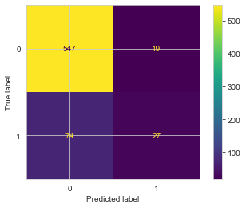

```python
#metric of baseline model and draw confusion matrix
evaluate_model_metrics(logreg, X_train_smote,y_train_smote, X_test, y_test)
```

### Model Performance Summary

**Observations**:

- The model shows a high level of discrimination on the training data but significantly lower on the test data, suggesting potential overfitting.
- The confusion matrix indicates a considerable number of false negatives, highlighting the need for model improvement.

### Cross-Validation

```python
# Create an instance of Logistic Regression with cross-validation
logreg_final = LogisticRegressionCV(Cs=10, cv=5, solver='liblinear')

# Fit the model on the resampled training data
logreg_final.fit(X_train_smote, y_train_smote)

# Predict on the resampled training and testing data
y_train_pred = logreg.predict(X_train_smote)
y_test_pred = logreg.predict(X_test)

# Calculate accuracy on the resampled training and testing data
train_accuracy = accuracy_score(y_train_smote, y_train_pred)
test_accuracy = accuracy_score(y_test, y_test_pred)
```

```
{'roc_auc_train': 0.8922942206654991,
 'roc_auc_test': 0.6177623062659623,
 'accuracy_train': 0.8922942206654991,
 'accuracy_test': 0.8620689655172413,
 'confusion_matrix_train': <sklearn.metrics._plot.confusion_matrix.ConfusionMatrixDisplay at 0x123ccac9e80>}
```

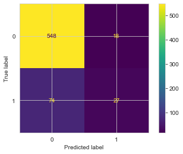

```python
evaluate_model_metrics(logreg_final,X_train_smote,y_train_smote,X_test,y_test)
```

## Decison Trees classifier model

```python
#DecisionTreeClassifier
dt_clf = DecisionTreeClassifier(max_depth=5, min_samples_split=5)

# Fit the model on the training data
dt_clf.fit(X_train_smote, y_train_smote)

# Predict on the training and testing data
y_train_pred_2= dt_clf.predict(X_train_smote)
y_test_pred_2 = dt_clf.predict(X_test)

# Calculate accuracy on the training and testing data
train_accuracy = accuracy_score(y_train_smote, y_train_pred)
test_accuracy = accuracy_score(y_test, y_test_pred_2)
```

```
{'roc_auc_train': 0.8857267950963224,
 'roc_auc_test': 0.8704212294020922,
 'accuracy_train': 0.8857267950963222,
 'accuracy_test': 0.9250374812593704,
 'confusion_matrix_train': <sklearn.metrics._plot.confusion_matrix.ConfusionMatrixDisplay at 0x123cd32fbe0>}
```

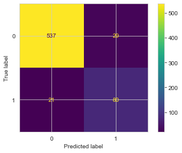

```python
#checking for decison tree metrics using the predefiend function
evaluate_model_metrics(dt_clf, X_train_smote, y_train_smote, X_test, y_test)
```

### Classification Report Summary

- **Precision**:
  - Class 0: 96.2%
  - Class 1: 73.3%
- **Recall**:
  - Class 0: 94.9%
  - Class 1: 79%
- **F1-score**:
  - Class 0: 95.6%
  - Class 1: 76.2%
- **Accuracy**:
  - Overall: 92.5%
- **Macro Average**:
  - Precision: 84.8%
  - Recall: 87.0%
  - F1-score: 85.9%
- **Weighted Average**:
  - Precision: 92.8%
  - Recall: 92.5%
  - F1-score: 92.6%

**Observations**:

- High precision and recall for class 0, indicating strong performance in identifying true negatives.
- Reasonable precision and recall for class 1, though with room for improvement in identifying true positives.
- Overall accuracy of 92.5%, suggesting robust performance across all instances.
- Balanced macro and weighted averages, indicating consistent performance across both classes.

> To gain further insights, we will examine the classification report for all metrics related to the Decision Tree classifier.

```python
#using predefined function to check for classification report
dt_clf_report = generate_classification_report(y_test, y_test_pred_2)
dt_clf_report
```

|  | precision | recall | f1-score | support |
| --- | --- | --- | --- | --- |
| 0 | 0.962366 | 0.948763 | 0.955516 | 566.000000 |
| 1 | 0.733945 | 0.792079 | 0.761905 | 101.000000 |
| accuracy | 0.925037 | 0.925037 | 0.925037 | 0.925037 |
| macro avg | 0.848155 | 0.870421 | 0.858710 | 667.000000 |
| weighted avg | 0.927777 | 0.925037 | 0.926199 | 667.000000 |

- Precision: In class 0, the precision is 0.962, indicating that 96.2% of the instances predicted as class 0 are actually true negatives. In class 1, the precision is 0.733, meaning that 73.3% of the instances predicted as class 1 are true positives.
- Recall: In class 0, the recall is 0.949, indicating that 94.9% of the actual class 0 instances are correctly identified as true negatives. In class 1, the recall is 0.79, meaning that 79% of the actual class 1 instances are correctly identified as true positives.
- F1-score: In class 0, the F1-score is 0.956, indicating a good balance between precision and recall for class 0. In class 1, the F1-score is 0.762, suggesting a slightly lower balance between precision and recall for class 1.
- Accuracy: Accuracy is the overall proportion of correctly classified instances. In this case, the accuracy is 0.925, meaning that the model correctly predicts the class labels for 92.5% of the instances.
- Macro avg: Macro average calculates the average metrics (precision, recall, F1-score) for both classes, giving equal weight to each class which are 0.848155, 0.870421 and 0.858710 while Weighted avg calculates the average metrics, taking into account the support (number of instances) for each class. It provides a weighted average based on the number of instances in each class which are 0.927777, 0.925037 and 0.926199.

### Random forest model

```python
#random forest classifier with regularization parameters
forest_classifier = RandomForestClassifier(n_estimators=100, max_depth=5, min_samples_split=5, max_features='sqrt', random_state=42)

# Fit the model on the selected training data
forest_classifier.fit(X_train_smote, y_train_smote)

# Predict on the training and testing sets
y_train_pred_3 = forest_classifier.predict(X_train_smote)
y_test_pred_3 = forest_classifier.predict(X_test)

# Calculate training and testing accuracy
train_accuracy = accuracy_score(y_train_smote, y_train_pred)
test_accuracy = accuracy_score(y_test, y_test_pred_3)
```

```
{'roc_auc_train': 0.8712784588441331,
 'roc_auc_test': 0.8191669873701151,
 'accuracy_train': 0.8712784588441331,
 'accuracy_test': 0.8725637181409296,
 'confusion_matrix_train': <sklearn.metrics._plot.confusion_matrix.ConfusionMatrixDisplay at 0x123cd0eea00>}
```

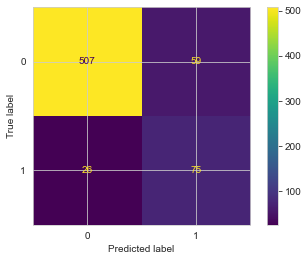

```python
#checking for random forest metrics using the predefiend function
evaluate_model_metrics(forest_classifier, X_train_smote, y_train_smote, X_test, y_test)
```

```python
generate_classification_report(y_test, y_test_pred_3)
```

|  | precision | recall | f1-score | support |
| --- | --- | --- | --- | --- |
| 0 | 0.951220 | 0.895760 | 0.922657 | 566.000000 |
| 1 | 0.559701 | 0.742574 | 0.638298 | 101.000000 |
| accuracy | 0.872564 | 0.872564 | 0.872564 | 0.872564 |
| macro avg | 0.755461 | 0.819167 | 0.780477 | 667.000000 |
| weighted avg | 0.891934 | 0.872564 | 0.879598 | 667.000000 |

> For class 0 (negative class):
- Precision: A value of 95.1% means that when the model predicts the negative class, it is correct 95.1% of the time.
- Recall: At 89.6%, this indicates that the model correctly identifies 89.6% of the actual negative instances.
- F1-score: With a value of 92.2%, this metric provides a balanced measure of precision and recall, combining both into a single value.
- Support: There are 566 instances of the negative class in the dataset.

### Summary

- Based on the analysis of the three models, it is evident that logistic regression performs poorly in predicting customer churn.
- In contrast, both the Random Forest classifier and Decision Trees perform well with accuracies of 87.3% and 92.5%, respectively.
- Therefore, it is crucial to enhance the performance of the Random Forest classifier and Decision Trees by tuning hyperparameters to achieve even better accuracy.
- Hyperparameters are essential for improving the efficiency and performance of models.

### Random Forest

```python
# Create an instance of the Random Forest classifier
forest= RandomForestClassifier( random_state=42)

# Define the parameter grid for grid search
forest_param_grid = {
    'n_estimators': [100, 200],
    'criterion': ['gini', 'entropy'],
    'max_depth': [2,6, 10],
    'min_samples_split': [5, 10],
    'min_samples_leaf': [3, 6]
}

# Create the GridSearchCV object
grid_search = GridSearchCV(estimator=forest, param_grid=forest_param_grid, cv=5, n_jobs=-1)

# Fit the grid search to the resampled training data
grid_search.fit(X_train_smote, y_train_smote)

# Get the best hyperparameters found during the grid search
best_params = grid_search.best_params_

# Create a new Random Forest classifier with the best hyperparameters
best_model = RandomForestClassifier(**best_params, random_state=42)

# Fit the best model to the resampled training data
best_model.fit(X_train_smote, y_train_smote)

# Predict on the training data
y_train_pred = best_model.predict(X_train_smote)

# Predict on the test data
y_test_pred = best_model.predict(X_test)

# Compute the accuracy
accuracy_train = accuracy_score(y_train_smote, y_train_pred)
accuracy_test = accuracy_score(y_test, y_test_pred)
```

```
{'roc_auc_train': 0.9358581436077057,
 'roc_auc_test': 0.8591033131581709,
 'accuracy_train': 0.9358581436077058,
 'accuracy_test': 0.9265367316341829,
 'confusion_matrix_train': <sklearn.metrics._plot.confusion_matrix.ConfusionMatrixDisplay at 0x123cd638100>}
```

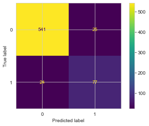

```python
#using the function above the draw confusion matrix
evaluate_model_metrics(best_model, X_train_smote, y_train_smote, X_test, y_test)
```

```python
# Define the parameter grid for grid search
dt_param_grid = {
    'max_depth': [3, 5, 7],
    'min_samples_split': [2, 5, 10],
    'min_samples_leaf': [1, 2, 4]
}

# Create an instance of DecisionTreeClassifier
dt_clf_final= DecisionTreeClassifier()

# Create the GridSearchCV object
grid_search = GridSearchCV(estimator=dt_clf_final, param_grid=dt_param_grid, cv=5)

# Fit the grid search to the resampled training data
grid_search.fit(X_train_smote, y_train_smote)

# Get the best hyperparameters found during the grid search
best_params = grid_search.best_params_

# Create a new DecisionTreeClassifier with the best hyperparameters
best_model_2 = DecisionTreeClassifier(**best_params)

# Fit the best model to the resampled training data
best_model_2.fit(X_train_smote, y_train_smote)

# Predict on the training and test data
y_train_pred = best_model_2.predict(X_train_smote)
y_test_pred = best_model_2.predict(X_test)

# Calculate accuracy on the training and test data
train_accuracy = accuracy_score(y_train_smote, y_train_pred)
test_accuracy = accuracy_score(y_test, y_test_pred)
```

```
{'roc_auc_train': 0.9043345008756568,
 'roc_auc_test': 0.8888062834552006,
 'accuracy_train': 0.9043345008756567,
 'accuracy_test': 0.9355322338830585,
 'confusion_matrix_train': <sklearn.metrics._plot.confusion_matrix.ConfusionMatrixDisplay at 0x123cbe41700>}
```

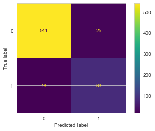

```python
evaluate_model_metrics(best_model_2, X_train_smote, y_train_smote, X_test, y_test)
```

### ROC curve to check the best model

[figure not shown]

```python
#drawing ROC curve for the above three models

# Compute ROC curves and AUC scores for each model
models = [best_model_2, logreg_final, best_model]
labels = ['Random Forest', 'Logistic Regression', 'Decision Tree']

plt.figure(figsize=(8, 6))

for model, label in zip(models, labels):
    if hasattr(model, "predict_proba"):
        y_probs = model.predict_proba(X_test)[:, 1]
    else:
        y_probs = model.predict(X_test)
    fpr, tpr, _ = roc_curve(y_test, y_probs)
    auc_score = roc_auc_score(y_test, y_probs)

    plt.plot(fpr, tpr, label='{} (AUC = {:.2f})'.format(label, auc_score))

plt.plot([0, 1], [0, 1], 'k--')
plt.xlabel('False Positive Rate')
plt.ylabel('True Positive Rate')
plt.title('Receiver Operating Characteristic (ROC) Curves')
plt.legend()
plt.show()
```